# G4058 Final Project

Fu, Wen & Lau, Arnold

December 20, 2015

### 1. Introduction

This project will be using a dataset from Paralyzed Veterans of America (PVA) that was previously used for the 1998 Knowledge Discovery and Data Mining (KDD) Cup. The dataset consists of 191,779 donors who have donated to PVA at least once between June 1995 and June 1996, but who have not donated anything between June 1996 and June 1997. These are referred to as “lapsed” donors, or donors who made their last donation 13 to 24 months ago. These donors were subsequently all solicited for a promotional campaign in June 1997. The variable to be predicted is **TARGET_B**, which tallies whether or not the donor responded to the June 1997 promotion.

```r
options(java.parameters = "-Xmx6g") # set 6GB of memory aside for the Java heap space for bartMachine()
library(dplyr)
library(lattice)
train <- read.table("KDD/cup98lrn/cup98LRN.txt", header = TRUE, sep = ",", skipNul = TRUE)
dim(train)
```

```
## [1] 95412   481
```

```r
test <- read.table("KDD/cup98val/cup98VAL.txt", header = TRUE, sep = ",", skipNul = TRUE)
# test_targets contains two response variables: whether or not a donor responded to the campaign,
# and how much money they gave if they did. In this project we are only predicting whether or not
# a donor responded, i.e. classification.
test_targets <- read.table("KDD/valtargt.txt", header = TRUE, sep = ",", skipNul = TRUE)
# bind the response variable to the testing data via the unique id CONTROLN
test <- arrange(test, CONTROLN)
test <- cbind(test, test_targets[,2:3])
rm(test_targets)
dim(test)
```

```
## [1] 96367   481
```

Due to the use of computationally intensive methods, we take a random sample of 10000 observations from the training set and 10000 observations from the testing set to predict with. (Otherwise, algorithms like bartMachine would take hours.)

```r
set.seed(4058)
train_samp <- sample_n(train, 10000)
test_samp <- sample_n(test, 10000)
rm(train, test)
```

### 2. Feature Selection & Description

The dataset was previously divided by the contest organizers into a training set with 95,412 observations and a testing set with 96,367 observations. There are a total of 481 features in the dataset, some of which are more relevant than others. For this project we extracted only a selection of variables that we judged would be better predictors of the response variable. We also recoded some of the variables when appropriate. In order to make the recoding less redundant, we combine the training and testing data first and then resplit them after recoding is complete. Descriptions of each variable follow.

```r
combi <- rbind(train_samp, test_samp)
sub <- c("PVASTATE", "DOMAIN", "AGE", "HOMEOWNR", "WEALTH2", "STATE", "GENDER", "HIT", "MALEMILI",
         "MALEVET", "VIETVETS", "WWIIVETS", "LOCALGOV", "STATEGOV", "FEDGOV", "MAJOR", "VETERANS",
         "PEPSTRFL", "ETH7", "ETH10", "ETH11", "AFC1", "AFC2", "AFC3", "AFC4", "AFC5", "AFC6",
         "VC1", "VC2", "VC3", "VC4", "NUMPRM12", "CARDGIFT", "TIMELAG", "AVGGIFT", "LASTGIFT", "RFA_2R",
         "RFA_2F", "RFA_2A", "RFA_3", "MDMAUD_R", "MDMAUD_F", "MDMAUD_A", "TARGET_B")
combi_sub <- combi[, sub]
```

- **PVASTATE** indicates whether the donor lives in a state served by a PVA chapter. This variable distinguishes between PVA chapters and EPVA (Eastern Paralyzed Veterans of America) chapters, a distinction which we do not think is important, so we create a new variable **PVASTATE_BIN** which is just 1 if **PVASTATE** is “E” or “P” and 0 otherwise.

```r
summary(train_samp$PVASTATE)
```

```
##         E    P
## 9841    1  158
```

```r
combi_sub$PVASTATE_BIN[combi_sub$PVASTATE == "E" | combi_sub$PVASTATE == "P"] <- 1
combi_sub$PVASTATE_BIN[combi_sub$PVASTATE != "E" & combi_sub$PVASTATE != "P"] <- 0
combi_sub$PVASTATE_BIN <- as.factor(combi_sub$PVASTATE_BIN)
```

- Each value in **DOMAIN** is two characters. The first character describes whether the donor’s neighborhood is urban, city, suburban, town or rural. The second character classifies the socio-economic status (SES) of the donor’s neighborhood as highest, average or lowest. We split **DOMAIN** into two separate variables **URBANICITY** and **NBHOOD_SES**. City, suburban, town and rural areas all had 3 categories of SES, while urban areas had 4, replacing “average” with “above average” and “below average”. In coding **NBHOOD_SES** we consider both as just “average”. Missing values are given their own category, “not mentioned”, in order to accommodate algorithms that won’t run with missing values (such as randomForest).

```r
summary(train_samp$DOMAIN)
```

```
##        C1   C2   C3   R1   R2   R3   S1   S2   S3   T1   T2   T3   U1   U2
##  253  626  854  537  156 1443  492 1226  889  188  490 1345  221  490  355
##   U3   U4
##  261  174
```

```r
combi_sub$URBANICITY[substr(combi_sub$DOMAIN, 1, 1) == "U"] <- "Urban"
combi_sub$URBANICITY[substr(combi_sub$DOMAIN, 1, 1) == "C"] <- "City"
combi_sub$URBANICITY[substr(combi_sub$DOMAIN, 1, 1) == "S"] <- "Suburban"
combi_sub$URBANICITY[substr(combi_sub$DOMAIN, 1, 1) == "T"] <- "Town"
combi_sub$URBANICITY[substr(combi_sub$DOMAIN, 1, 1) == "R"] <- "Rural"
combi_sub$URBANICITY[combi_sub$DOMAIN == " "] <- "Not mentioned"
combi_sub$URBANICITY <- as.factor(combi_sub$URBANICITY)

combi_sub$NBHOOD_SES[substr(combi_sub$DOMAIN, 2, 2) == "1"] <- "Highest SES"
combi_sub$NBHOOD_SES[substr(combi_sub$DOMAIN, 2, 2) == "2"] <- "Average SES"
combi_sub$NBHOOD_SES[substr(combi_sub$DOMAIN, 2, 2) == "3" &
                     substr(combi_sub$DOMAIN, 1, 1) == "U"] <- "Average SES"
combi_sub$NBHOOD_SES[substr(combi_sub$DOMAIN, 2, 2) == "3" &
                     substr(combi_sub$DOMAIN, 1, 1) != "U"] <- "Lowest SES"
combi_sub$NBHOOD_SES[substr(combi_sub$DOMAIN, 2, 2) == "4"] <- "Lowest SES"
combi_sub$NBHOOD_SES[combi_sub$DOMAIN == " "] <- "Not mentioned"
combi_sub$NBHOOD_SES <- as.factor(combi_sub$NBHOOD_SES)
```

```r
summary(train_samp$AGE)
```

```
##    Min. 1st Qu.  Median    Mean 3rd Qu.    Max.    NA's
##    7.00   48.00   62.00   61.49   75.00   98.00    2465
```

```r
train_samp$AGE_MISSING <- ifelse(is.na(train_samp$AGE), 1, 0)
prop.table(table(train_samp$AGE_MISSING, train_samp$TARGET_B), margin = 1)
```

```
##
##              0          1
##   0 0.94452555 0.05547445
##   1 0.95212982 0.04787018
```

- **HOMEOWNR** is “H” if the donor is a known homeowner, “U” if unknown, and then there are 2,329 missing values. We recode this int **HOMEOWNR_BIN** which is 1 if the donor is a known homeowner and 0 otherwise.

```r
combi_sub$HOMEOWNR_BIN[combi_sub$HOMEOWNR == "H"] <- 1
combi_sub$HOMEOWNR_BIN[combi_sub$HOMEOWNR == "U"] <- 0
combi_sub$HOMEOWNR_BIN[combi_sub$HOMEOWNR == " "] <- 0
combi_sub$HOMEOWNR_BIN <- as.factor(combi_sub$HOMEOWNR_BIN)
```

- **WEALTH2** indexes relative wealth within each state, with 0 being the lowest income group and 9 being the highest. We recode this as **WEALTH2_CAT**, a factor.

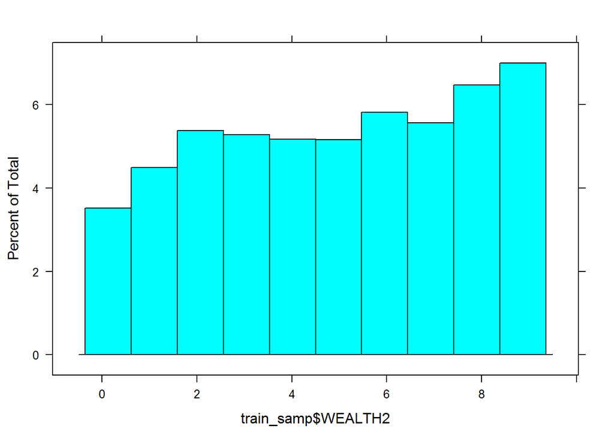

```r
histogram(train_samp$WEALTH2, nint = 10)
```

```r
combi_sub$WEALTH2_CAT <- as.factor(combi_sub$WEALTH2)
```

- **STATE** includes all 50 U.S states and the District of Columbia, as well as mail from U.S. armed forces stationed in various parts of the world (“AA”, “AE”, “AP”), American Samoa, Guam, and the Virgin Islands.

```r
summary(train_samp$STATE)
```

```
##   AA   AE   AK   AL   AP   AR   AS   AZ   CA   CO   CT   DC   DE   FL   GA
##    2    2   33  158    9   85    1  223 1825  200    3    0    1  896  352
##   GU   HI   IA   ID   IL   IN   KS   KY   LA   MA   MD   ME   MI   MN   MO
##    0   47  146   55  707  288  141  183  150    3    2    1  590  230  280
##   MS   MT   NC   ND   NE   NH   NJ   NM   NV   NY   OH   OK   OR   PA   RI
##   95   54  434   29   82    2    2   84  112   11    3  177  235    2    0
##   SC   SD   TN   TX   UT   VA   VI   VT   WA   WI   WV   WY
##  212   31  276  804   53    6    1    1  359  298    0   24
```

- **GENDER** includes “U” for Unknown and “J” for Joint Account, along with “M” for Male and “F” for Female. There are also possible coding errors “A” and “C” in the data, and 327 missing values coded as " “. We preserve this coding and consider”A“,”C“, and”U" to be " " as well.

```r
combi_sub$GENDER[combi_sub$GENDER == "A"] <- " "
combi_sub$GENDER[combi_sub$GENDER == "C"] <- " "
combi_sub$GENDER[combi_sub$GENDER == "U"] <- " "
```

- **HIT** indicates the total number of known times the donor has responded to a mail order offer other than PVA’s. For some reason, there are an unusually high number of observations with the value of 240, but there isn’t any indication in the data’s documentation what significance 240 might have. The next lowest value after 240 is 84.

```r
summary(train_samp$HIT)
```

```
##    Min. 1st Qu.  Median    Mean 3rd Qu.    Max.
##   0.000   0.000   0.000   3.299   3.000 240.000
```

- **MALEMILI**, **MALEVET**, **VIETVETS** and **WWIIVETS** are neighborhood-level variables recording % males active in the military, % male veterans, % Vietnam veterans, and % WWII veterans respectively, as reported by a third-party data source. **AFC2**, **AFC5**, **VC1** and **VC3** record the same thing as the above variables but come from 1990 census data. The other variables like this are **AFC1** (% adults in active military service), **AFC3** (% females in active military service), **AFC4** (% adult veterans age 16+), **AFC6** (% female veterans age 16+), **VC2** (% Korean veterans age 16+), and **VC4** (% veterans serving after May 1975 only).

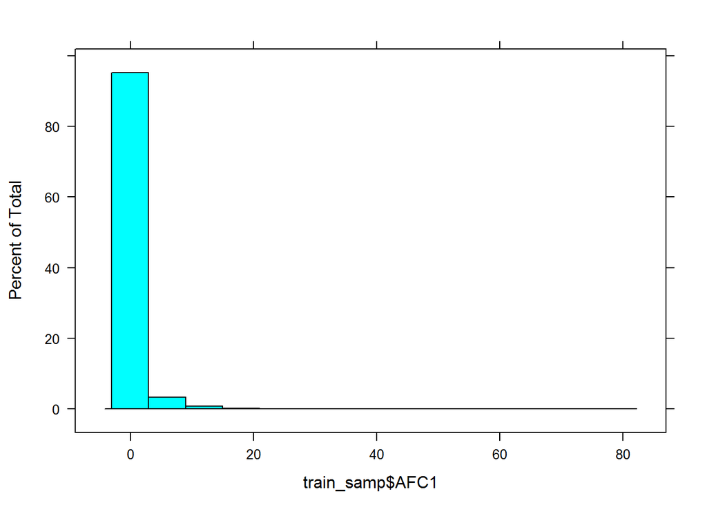

```r
histogram(train_samp$AFC1)
```

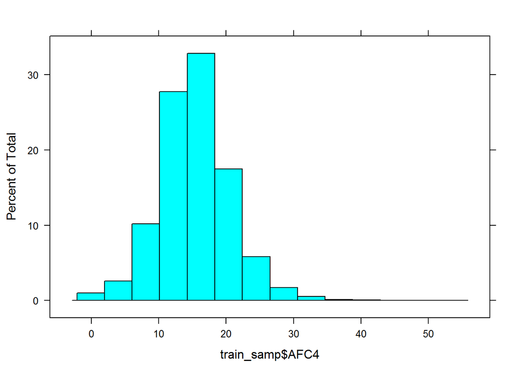

```r
histogram(train_samp$AFC4)
```

- **ETH7**, **ETH10** and **ETH11** are neighborhood-level variables recording % Japanese, % Korean and % Vietnamese respectively. We think there’s a small possibility that these ecological variables have an impact on the predictor - maybe an inverse relationship of some sort. In any case, tree-based methods will assign very low importance to these variables if they turn out to not be relevant after all. The same logic goes for the “veteran” variables above.

```r
### Rename ETH7, ETH10 and ETH11 for descriptiveness
combi_sub$JAPANESE <- combi_sub$ETH7
combi_sub$KOREAN <- combi_sub$ETH10
combi_sub$VIETNAMESE <- combi_sub$ETH11
```

```r
summary(train_samp$NUMPRM12)
```

```
##    Min. 1st Qu.  Median    Mean 3rd Qu.    Max.
##    2.00   11.00   12.00   12.84   13.00   47.00
```

- **CARDGIFT** is the number of gifts that a donor has ever made to a promotion over their lifetime. The median is 4 and the mode is 1. The values range from 0 to 41. This does not include unsolicited donations - there are 520 donors who have never given solicited donations, but have donated in some other fashion. (As previously stated, everyone in the dataset has donated at least once.)

```r
summary(train_samp$CARDGIFT)
```

```
##    Min. 1st Qu.  Median    Mean 3rd Qu.    Max.
##   0.000   2.000   4.000   5.063   7.000  41.000
```

```r
summary(train_samp$TIMELAG)
```

```
##    Min. 1st Qu.  Median    Mean 3rd Qu.    Max.    NA's
##   0.000   4.000   6.000   8.082  11.000  50.000    1020
```

```r
combi_sub$TIMELAG[combi_sub$TIMELAG > 400] <- NA
```

- **AVGGIFT** is the average dollar amount of all donations from each donor to date. The mean is 13.45 and the median is 11.5, but there are quite a few larger gifts.

```r
summary(train_samp$AVGGIFT)
```

```
##    Min. 1st Qu.  Median    Mean 3rd Qu.    Max.
##   1.500   8.364  11.500  13.450  15.500 300.000
```

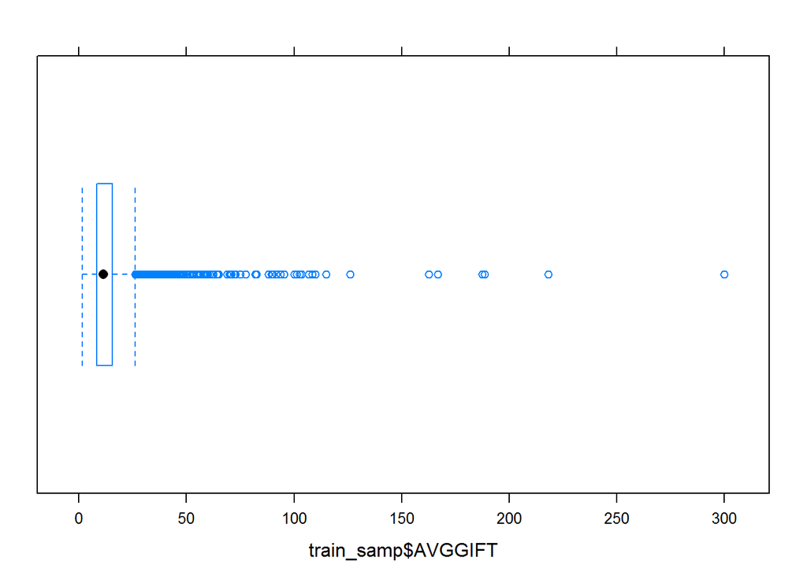

```r
bwplot(train_samp$AVGGIFT)
```

- **LASTGIFT** is the dollar amount of the most recent donation made by a donor. The mean is 17.42 and the median is 15.00.

```r
summary(train_samp$LASTGIFT)
```

```
##    Min. 1st Qu.  Median    Mean 3rd Qu.    Max.
##    0.00   10.00   15.00   17.42   20.00  300.00
```

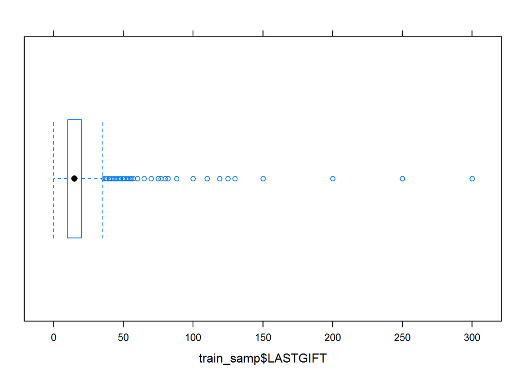

```r
bwplot(train_samp$LASTGIFT)
```

- **RFA_2R**, **RFA_2F**, **RFA_2A**, and **RFA_3** are “recency, frequency, amount” variables common in direct marketing. These variables range from **RFA_2** to **RFA_24** in the data, where each number refers to a particular promotion, in reverse date order (i.e. **RFA_2** is the most recent promotion, June 1997, and **RFA_24** is the earliest promotion, May-June 1994). Each category in an RFA variable consists of three characters. The first character is the donor’s recency status (first-time, active, inactive, etc), the second is how many donations they gave within the last 12 months (or less) that they were active, and the third character categorizes the amount of their most recent gift as of the date of that promotion. Note that since this dataset only gathers people who have not donated anything between June 1996 and June 1997, the recency (R) status of every single person in the dataset for promotion 2 is L (Lapsed):

```r
table(train_samp$RFA_2R)
```

```
##
##     L
## 10000
```

We can thus look at individual donor history across 23 promotions, looking at changes in their status for example, but for this project we just focus on promotion 2 (June 1997), responses to which are measured by **TARGET_B**, and promotion 3 (June 1996). The dataset already came with **RFA_2** split up into R, F and A; we do the same to **RFA_3**, creating new variables **RFA_3R**, **RFA_3F**, and **RFA_3A**.

```r
### Split RFA_3 into R, F, and A. RFA_3 describes promotions given out June 1996 (18 were given out April 1996)
combi_sub$RFA_3R[substr(combi_sub$RFA_3, 1, 1) == "F"] <- "First time donor"
combi_sub$RFA_3R[substr(combi_sub$RFA_3, 1, 1) == "I"] <- "Inactive donor"
combi_sub$RFA_3R[substr(combi_sub$RFA_3, 1, 1) == "N"] <- "New donor"
combi_sub$RFA_3R[substr(combi_sub$RFA_3, 1, 1) == "A"] <- "Active donor"
combi_sub$RFA_3R[substr(combi_sub$RFA_3, 1, 1) == "L"] <- "Lapsing donor"
combi_sub$RFA_3R[substr(combi_sub$RFA_3, 1, 1) == "S"] <- "Star donor" # gave to three or more promos consecutively
combi_sub$RFA_3R[combi_sub$RFA_3 == " "] <- "Not mailed"
combi_sub$RFA_3R <- as.factor(combi_sub$RFA_3R)

combi_sub$RFA_3F[substr(combi_sub$RFA_3, 2, 2) == "1"] <- "One gift"
combi_sub$RFA_3F[substr(combi_sub$RFA_3, 2, 2) == "2"] <- "Two gifts"
combi_sub$RFA_3F[substr(combi_sub$RFA_3, 2, 2) == "3"] <- "Three gifts"
combi_sub$RFA_3F[substr(combi_sub$RFA_3, 2, 2) == "4"] <- "Four or more gifts"
combi_sub$RFA_3F[combi_sub$RFA_3 == " "] <- "Not mailed"
combi_sub$RFA_3F <- as.factor(combi_sub$RFA_3F)

combi_sub$RFA_3A[substr(combi_sub$RFA_3, 3, 3) == "A"] <- "$0.01 - $1.99"
combi_sub$RFA_3A[substr(combi_sub$RFA_3, 3, 3) == "B"] <- "$2.00 - $2.99"
combi_sub$RFA_3A[substr(combi_sub$RFA_3, 3, 3) == "C"] <- "$3.00 - $4.99"
combi_sub$RFA_3A[substr(combi_sub$RFA_3, 3, 3) == "D"] <- "$5.00 - $9.99"
combi_sub$RFA_3A[substr(combi_sub$RFA_3, 3, 3) == "E"] <- "$10.00 - $14.99"
combi_sub$RFA_3A[substr(combi_sub$RFA_3, 3, 3) == "F"] <- "$15.00 - $24.99"
combi_sub$RFA_3A[substr(combi_sub$RFA_3, 3, 3) == "G"] <- "$25.00 and above"
combi_sub$RFA_3A[combi_sub$RFA_3 == " "] <- "Not mailed"
combi_sub$RFA_3A <- as.factor(combi_sub$RFA_3A)
```

- **PEPSTRFL** indicates PEP Star RFA Status. We’re not actually sure what this means, but it seems to indicate a type of priority donor.

```r
table(train_samp$PEPSTRFL)
```

```
##
##         X
## 5251 4749
```

- **MAJOR** indicates whether a donor has ever given a $100+ donation at any point. In the training data, only 38 donors have done so.

```r
table(train_samp$MAJOR)
```

```
##
##         X
## 9962   38
```

- **MDMAUD_R**, **MDMAUD_F**, and **MDMAUD_A** are the recency, frequency, and amount variables for major donors. These are coded differently from the other RFA variables. Recency is coded as C for Current Donor, L for Lapsed, I for Inactive and D for Dormant; frequency is coded as 1 for one gift, 2 for two-four gifts and 5 for five+ gifts; amount is coded as L for “low dollar”, C for “core”, M for “major” and T for “top”.

```r
table(train_samp$MDMAUD_R)
```

```
##
##    C    D    I    L    X
##   14   13    3    8 9962
```

```r
table(train_samp$MDMAUD_F)
```

```
##
##    1    2    5    X
##   22   13    3 9962
```

```r
table(train_samp$MDMAUD_A)
```

```
##
##    C    L    M    T    X
##   30    3    3    2 9962
```

Finally, we make the response variable a factor and then resplit into training and testing data.

```r
combi_sub$TARGET_B <- as.factor(combi_sub$TARGET_B)
train_sub <- combi_sub[1:10000, ]
test_sub <- combi_sub[10001:20000, ]
```

### 3. Modelling & Prediction

#### Bayesian Additive Regression Trees using bartMachine

We pass a model predicting **TARGET_B** from variables selected to avoid redundancy (e.g. we didn’t use all the neighborhood-level variables). We also set use_missing_data = TRUE and use_missing_data_dummies_as_covars = TRUE in order to take into account Kapelner and Bleich (2013)’s method for using missing data without imputation.

```r
library(bartMachine)
set_bart_machine_num_cores(parallel::detectCores())
```

```
## bartMachine now using 4 cores.
```

```r
bart_fit <- bartMachine(X = train_sub[, c(6:8, 16:18, 22, 25, 32:36, 38:39, 41:43, 45:55)],
                        y = train_sub$TARGET_B, mem_cache_for_speed = FALSE, use_missing_data = TRUE,
                        use_missing_data_dummies_as_covars = TRUE)
```

```
## bartMachine initializing with 50 trees...
## Now building bartMachine for classification ...Covariate importance prior ON. Missing data feature ON. Missingness used as covariates.
## evaluating in sample data...done
```

```r
bart_fit
```

```
## bartMachine v1.2.1 for classification
##
## Missing data feature ON
## training data n = 10000 and p = 146
## built in 1.14 mins on 4 cores, 50 trees, 250 burn-in and 1000 post. samples
##
## confusion matrix:
##
##            predicted 0 predicted 1 model errors
## actual 0      9464.000           0        0.000
## actual 1       536.000           0        1.000
## use errors       0.054         NaN        0.054
```

```r
bart_fit_pred <- predict(bart_fit,
                         new_data = test_sub[, c(6:8, 16:18, 22, 25, 32:36, 38:39, 41:43, 45:55)],
                         type = "class")
table(test_sub$TARGET_B, bart_fit_pred)
```

```
##    bart_fit_pred
##        0    1
##   0 9482    0
##   1  518    0
```

The predictions from bartMachine are the same as predicting that nobody donates. What if we set the classification threshold lower, from 0.5 to 0.2, so that all predictions with a probability of 0.2 or higher will be classified as donors?

```r
bart_fit_20 <- bartMachine(X = train_sub[, c(6:8, 16:18, 22, 25, 32:36, 38:39, 41:43, 45:55)],
                           y = train_sub$TARGET_B, mem_cache_for_speed = FALSE, use_missing_data = TRUE,
                           use_missing_data_dummies_as_covars = TRUE,prob_rule_class = 0.2)
```

```
## bartMachine initializing with 50 trees...
## Now building bartMachine for classification ...Covariate importance prior ON. Missing data feature ON. Missingness used as covariates.
## evaluating in sample data...done
```

```r
bart_fit_20
```

```
## bartMachine v1.2.1 for classification
##
## Missing data feature ON
## training data n = 10000 and p = 146
## built in 1.2 mins on 4 cores, 50 trees, 250 burn-in and 1000 post. samples
##
## confusion matrix:
##
##            predicted 0 predicted 1 model errors
## actual 0      9464.000           0        0.000
## actual 1       536.000           0        1.000
## use errors       0.054         NaN        0.054
```

```r
bart_fit_20_pred <- predict(bart_fit_20,
                            new_data = test_sub[, c(6:8, 16:18, 22, 25, 32:36, 38:39, 41:43, 45:55)],
                            type = "class")
table(test_sub$TARGET_B, bart_fit_20_pred)
```

```
##    bart_fit_20_pred
##        0    1
##   0 9482    0
##   1  518    0
```

The revised model still does no better than predicting nobody donates, which means that all of the predicted probabilies are less than 0.2. Perhaps the variables we selected provided very little information for prediction, or that further tweaking of the parameters is necessary.

```
## .....
```

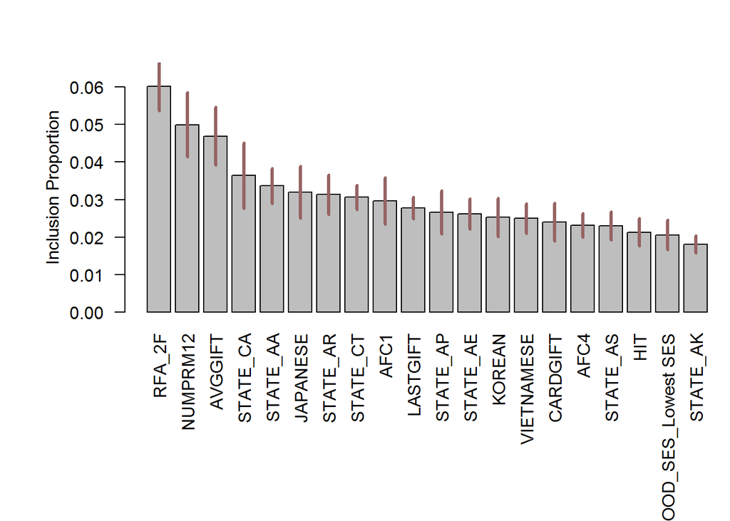

```r
investigate_var_importance(bart_fit, num_var_plot = 20) # display only 20 variables in the plot
```

According to the variable inclusion proportions plot of the fitted BART model, the most “important” variables in fitting the model were the frequency of gifts for the June 1997 promo period, the number of promotions received in the last 12 months, and the average dollar amount of all donations from each donor to date. Some state-level and neighborhood-level variables were important as well.

#### More pre-processing: Missing Data Imputation

```r
var <- c("PVASTATE_BIN", "URBANICITY", "NBHOOD_SES", "AGE", "HOMEOWNR_BIN", "WEALTH2_CAT", "GENDER", "HIT", "MAJOR", "VETERANS", "PEPSTRFL", "VIETNAMESE", "JAPANESE", "KOREAN", "AFC1", "AFC4", "NUMPRM12", "CARDGIFT", "TIMELAG", "AVGGIFT", "LASTGIFT", "RFA_2F", "RFA_2A", "RFA_3A", "RFA_3F", "RFA_3R", "MDMAUD_R", "MDMAUD_F", "MDMAUD_A", "TARGET_B")
train_sub_var <- train_sub[, var]
test_sub_var <- test_sub[, var]
```

Several of our selected features in the training set contain missing data. We think that while we could simply disregard missing values or omit the corresponding predictors, we could benefit from the available information by inferring the missing data from known values. bartMachine has built-in methods for dealing with missing data, but the other models we’re going to look at don’t.

```r
stopifnot(require(mice))
```

```
## mice 2.25 2015-11-09
```

```r
md.pattern(train_sub_var)
```

```
##      PVASTATE_BIN URBANICITY NBHOOD_SES HOMEOWNR_BIN GENDER HIT MAJOR
## 4389            1          1          1            1      1   1     1
##  995            1          1          1            1      1   1     1
## 2472            1          1          1            1      1   1     1
## 1124            1          1          1            1      1   1     1
##  674            1          1          1            1      1   1     1
##  346            1          1          1            1      1   1     1
##                 0          0          0            0      0   0     0
##      VETERANS PEPSTRFL VIETNAMESE JAPANESE KOREAN AFC1 AFC4 NUMPRM12
## 4389        1        1          1        1      1    1    1        1
##  995        1        1          1        1      1    1    1        1
## 2472        1        1          1        1      1    1    1        1
## 1124        1        1          1        1      1    1    1        1
##  674        1        1          1        1      1    1    1        1
##  346        1        1          1        1      1    1    1        1
```

[output cut: 17 more lines]

There are 4,389 (out of 10,000) rows in the training set that are complete. The variables with missing data are: `TIMELAG`, `AGE`, and `WEALTH2_CAT`. Most missing values occur in `WEALTH2_CAT` (4,616).

We decide to create multivariate imputation by chained equations. The algorithm imputes an incomplete column by generating synthetic values given other columns in the dataset.

```r
train_imp <- mice(train_sub_var, m = 5, maxit = 5)
```

To check whether the imputed data is plausible, we inspect some of the imputations for `AGE`, for example.

```r
train_imp$imp$AGE[1:50, ]
```

```
##        1  2  3  4  5
## 956   66 76 49 76 79
## 65139 56 84 73 51 34
## 27972  7 72 83 52 85
## 28064 76 94 76 65 58
## 32774 82 44 52 68 66
## 46351 30 60 72 74 76
## 13279 91 53 68 53 58
## 9044  78 34 59 42 47
## 81153 74 75 57 77 54
## 17947 43 54 44 67 36
## 95060 70 82 38 80 47
## 52453 96 34 62 59 39
## 44554 70 78 42 49 50
## 82887 50 86 90 63 71
```

[output cut: 36 more lines]

The observed and imputed data can be combined.

```r
train_com <- complete(train_imp)
dim(train_com)
```

```
## [1] 10000    30
```

Further, we check the distributions of the observed and imputed data for `TIMELAG`, for example. We think that the graph indicates that the distributions of blue (observed values) and red (imputed values) are similar.

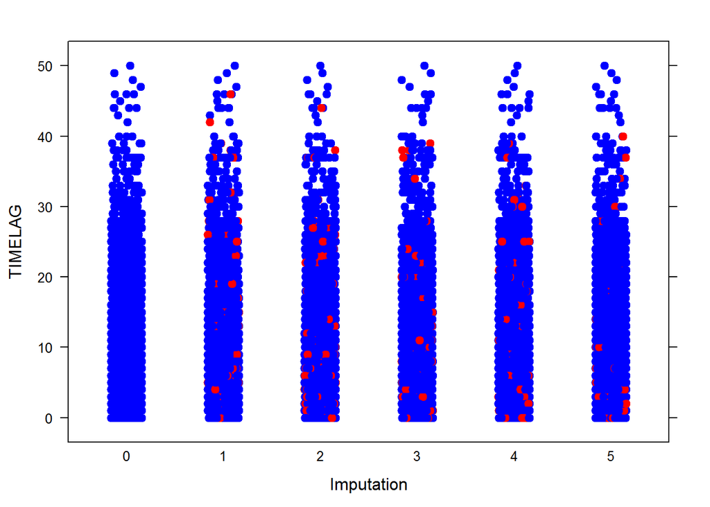

```r
com <- complete(train_imp, "long", include = TRUE)
col <- rep(c("blue", "red")[1 + as.numeric(is.na(train_imp$data$TIMELAG))], 6)  # Separates the observed (blue) and imputed (red) data
stripplot(TIMELAG ~.imp, data = com, jit = TRUE, fac = 0.8, col = col, pch = 20, cex = 1.4, xlab = "Imputation")
```

We impute the test data in a similar manner, assuming that they are drawn from the same distribution.

```r
test_imp <- mice(test_sub_var, m = 5, maxit = 5)
test_com <- complete(test_imp)
dim(test_com)
```

```
## [1] 10000    30
```

#### Multilayer Perceptrons

With the imputed data, we use a multilayer perceptron (a type of neural net) passing in the same predictors as before, except for STATE (because of the absence of data for one state in the testing set). The input data is transformed into a matrix and then normalized. The default arguments are used for the fit.

```r
library(RSNNS)
combi_com <- rbind(train_com, test_com)
combi_com_mat <- model.matrix(TARGET_B ~ ., data = combi_com)[, -1]
# Normalization: set continuous variables to mean 0 and sd 1
combi_com_mat[, c(10, 27, 31:40)] <- normalizeData(combi_com_mat[, c(10, 27, 31:40)])
train_com_mat <- combi_com_mat[1:10000, ]
test_com_mat <- combi_com_mat[10001:20000, ]
mlp_train_target <- decodeClassLabels(train_com$TARGET_B)
mlp_test_target <- decodeClassLabels(test_com$TARGET_B)
mlp_fit <- mlp(x = train_com_mat, y = mlp_train_target, size = c(5), maxit = 100,
               learnFunc = "Std_Backpropagation", inputsTest = test_com_mat,
               targetsTest = mlp_test_target)
mlp_pred <- predict(mlp_fit, test_com_mat)

confusionMatrix(mlp_train_target, fitted.values(mlp_fit))
```

```
##        predictions
## targets    1    2
##       1 9461    3
##       2  532    4
```

```r
confusionMatrix(mlp_test_target, encodeClassLabels(mlp_pred, method = "402040"))
```

```
##        predictions
## targets    0
##       1 9482
##       2  518
```

```r
confusionMatrix(mlp_test_target, encodeClassLabels(mlp_pred, method = "WTA"))
```

```
##        predictions
## targets    1    2
##       1 9475    7
##       2  518    0
```

The model fits the training data better than baseline (predicting nobody donates), but it performs either at baseline or worse than baseline, depending on the classification method. encodeClassLabels() converts continuous outputs from mlp to binary outputs for classification, and provides two ways of doing so. Using method “402040” gives us baseline predictions while method “WTA” does slightly worse than baseline.

#### Logistic Regression

```r
glm_fit <- glm(TARGET_B ~ ., data = train_com, family = "binomial"(link = "logit"))
glm_pred <- predict(glm_fit, newdata = test_com, type = "response")
table(test_com$TARGET_B, as.integer(glm_pred > 0.5))
```

```
##
##        0
##   0 9482
##   1  518
```

```r
table(test_com$TARGET_B, as.integer(glm_pred > 0.2))
```

```
##
##        0    1
##   0 9459   23
##   1  512    6
```

Fitting logistic regression on the imputed training data using a classification threshold of 0.5 performs at baseline. Lowering the classification threshold to 0.2 gives worse results, but produces some true positives.

```r
glm_new_fit <- glm(TARGET_B ~ LASTGIFT + AVGGIFT + CARDGIFT + NUMPRM12, data = train_com, family = "binomial"(link = "logit"))
glm_new_pred <- predict(glm_new_fit, newdata = test_com, type = "response")
table(test_com$TARGET_B, as.integer(glm_new_pred > 0.5))
```

```
##
##        0
##   0 9482
##   1  518
```

```r
table(test_com$TARGET_B, as.integer(glm_new_pred > 0.2))
```

```
##
##        0
##   0 9482
##   1  518
```

#### Random Forest

Next we fit a randomForest model, using the following predictors (same as the first `glm` model).

```r
stopifnot(require(randomForest))
rf_fit <- randomForest(TARGET_B ~ ., data = train_com, importance = TRUE)
rf_pred <- predict(rf_fit, newdata = test_com, type = "response")
rf_fit
```

```
##
## Call:
##  randomForest(formula = TARGET_B ~ ., data = train_com, importance = TRUE)
##                Type of random forest: classification
##                      Number of trees: 500
## No. of variables tried at each split: 5
##
##         OOB estimate of  error rate: 5.36%
## Confusion matrix:
##      0 1 class.error
## 0 9464 0           0
## 1  536 0           1
```

```r
table(test_com$TARGET_B, rf_pred)
```

```
##    rf_pred
##        0    1
##   0 9482    0
##   1  518    0
```

The confusion matrix in the model call suggests that the fit for the training set predicts that 0 people donate. The model on the testing set also predicts that 0 people donate.

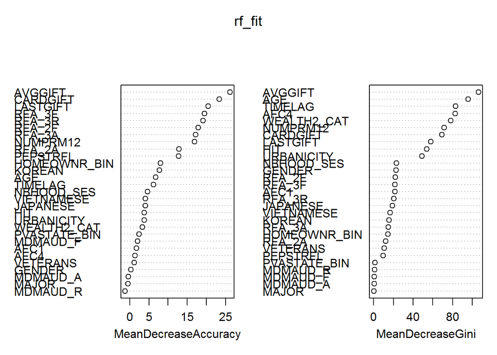

```r
par(mar = c(2,2,2,2))
varImpPlot(rf_fit)
```

Based on the “importance” scores of existing predictors, we update the list of predictors to include only the most important ones.

```r
rf_new_fit <- randomForest(TARGET_B ~ AVGGIFT + CARDGIFT + LASTGIFT + NUMPRM12, data = train_com, importance = TRUE)
rf_new_fit
```

```
##
## Call:
##  randomForest(formula = TARGET_B ~ AVGGIFT + CARDGIFT + LASTGIFT +      NUMPRM12, data = train_com, importance = TRUE)
##                Type of random forest: classification
##                      Number of trees: 500
## No. of variables tried at each split: 2
##
##         OOB estimate of  error rate: 5.55%
## Confusion matrix:
##      0  1 class.error
## 0 9445 19 0.002007608
## 1  536  0 1.000000000
```

```r
rf_new_pred <- predict(rf_new_fit, newdata = test_com, type = "response")
table(test_com$TARGET_B, rf_new_pred)
```

```
##    rf_new_pred
##        0    1
##   0 9468   14
##   1  515    3
```

## glmnet

We apply `glmnet` to classify donors via penalized maximum likelihood as objective function.

```r
stopifnot(require(glmnet))
X <- model.matrix(TARGET_B ~ ., data = train_com)
y <- train_com$TARGET_B
path <- glmnet(X[, -1], y, family = "binomial")
test_X <- model.matrix(TARGET_B ~ ., data = test_com)
path_pred <- predict(path, newx = test_X[, -1], type = "response")
z_path_pred <- path_pred > 0.5
class <- which.max(colSums(apply(z_path_pred, MARGIN = 2, FUN = "==", e2 = y)))
table(test_com$TARGET_B, as.integer(z_path_pred[, class]))
```

```
##
##        0
##   0 9482
##   1  518
```

### 4. Conclusion

Given the low proportion of donors in both the training and testing sets, it was difficult to develop a model that predicts better than baseline. The small variation in the response variable, as well as the great amount of missing data, both affect the performance of our classification models. The most viable point of improvement would be in feature selection.